# Bivariate Descriptive Statistics & Probability Distributions

Lecture 3 - LAS

Don van den Bergh

07-09-2026

## Today

[Chapter 5](https://cjvanlissa.github.io/stats12/Chapter3_Correlation.html) and [Chapter 6](https://cjvanlissa.github.io/stats12/probability.html) from the gitbook.

# Bivariate Descriptive Statistics

## What is “Bivariate”?

Looking at two variables at the same time.

Yes, there is also “trivariate” and more generally, “multivariate”.

## Bivariate Descriptive Statistics

- Contingency tables (we talked about these last week)
- Covariance
- Correlation

## Dataset: World Data

| name | child_mortality | fertility | co2_pcap | gdp_pcap | life_expectancy | daily_income |
| --- | --- | --- | --- | --- | --- | --- |
| Afghanistan | 52.52 | 4.93 | 0.284 | 1981.71017 | 68 | 3.6068 |
| Angola | 69.33 | 5.21 | 1.225 | 7397.48643 | 64 | 5.3361 |
| Albania | 9.06 | 1.36 | 2.103 | 17111.95393 | 78.7 | 17.3271 |
| Austria | 2.91 | 1.41 | 9.2 | 65661.45219 | 81.5 | 82.4267 |
| Belgium | 3.47 | 1.55 | 16.928 | 62744.203 | 81.6 | 68.3912 |
| Brazil | 13.78 | 1.63 | 2.109 | 18554.04618 | 76.1 | 24.361 |
| Canada | 4.64 | 1.37 | 13.173 | 58321.06118 | 81.2 | 83.8726 |
| Switzerland | 3.79 | 1.4 | 11.644 | 82777.29358 | 83.7 | 91.4699 |
| Chile | 5.46 | 1.26 | 4.544 | 29569.47755 | 79.6 | 32.7678 |
| China | 7.1 | 1.03 | 7.379 | 21499.38228 | 79.9 | 17.6715 |

[output cut: 20 more lines]

Source: Data from world bank via https://www.gapminder.org/data, CC-BY license

## Dataset: World Data

- Child mortality: Probability of dying between age 0 - 5 per 1000 babies (percentage).
- Fertility: This is the number of children that would be born to a woman if she were to live to the end of her childbearing years and bear children in accordance with age-specific fertility rates of the specified year.
- CO2_PCAP: CO2 emissions per capita.
- GDP_PCAP: GDP per capita.
- Life Expectancy: No. years a newborn would live at current mortality rates.
- Daily income: The mean daily household per capita income in 2021 PPP (constant international dollars).

## Fertility vs. Life expectancy

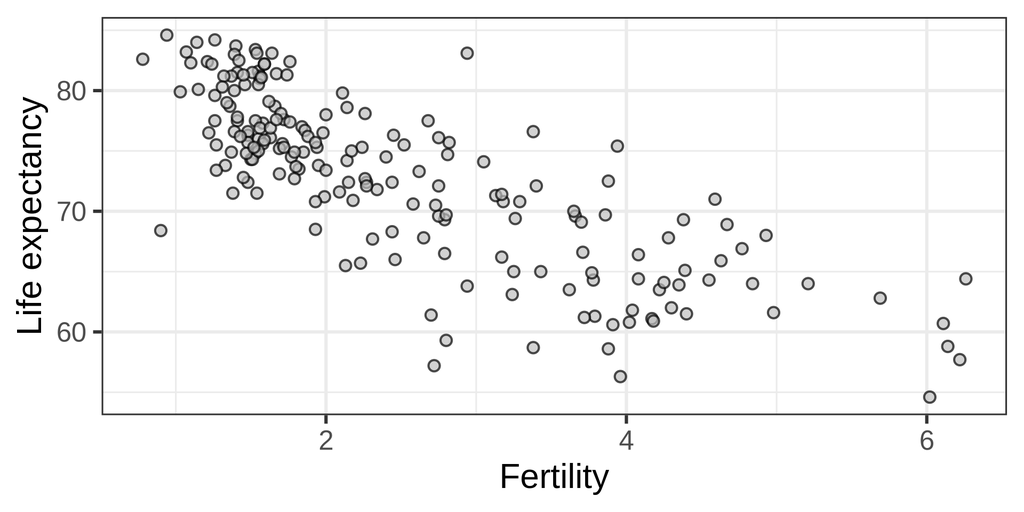

## Last Week: Sum of Squared Distances $SS_x$

$$SS_x = \sum_{i=1}^{n}(x_i - \bar{x})^2 = \sum_{i=1}^{n}(x_i - \bar{x})(x_i - \bar{x})$$

One variable: $\mathrm{deviation} \times \mathrm{deviation} = \mathrm{Variance}$

Two variables: $x\mathrm{-deviation} \times y\mathrm{-deviation} = \mathrm{Covariance}$

## Covariance: Sum of Products

$$SP_{xy} = \sum_{i=1}^n \bigl(x_i - \bar{x}\bigr)\bigl(y_i - \bar{y}\bigr)$$

Definitions:

- $x$ and $y$: the two variables we’re interested in.
- $\bar{x}$: the sample mean of the variable $x$.
- $x_i$: the $i$th observation of the variable.
- $n$ the sample size.
- $\sum_{i=1}^{n}$: the sum from $i$ is 1 to $i$ is $n$.
- $SP_{xy}$ the sum of products between $x$ and $y$.

## Covariance: Sum of Products

$\overline{\text{Life Expectancy}}$ = 72.8, $\overline{\text{Fertility}}$ = 2.5,

| name | life_expectancy | fertility | life_expectancy_m0 | fertility_m0 | SP |
| --- | --- | --- | --- | --- | --- |
| Afghanistan | 68 | 4.93 | -4.752061855670107 | 2.43276923076923 | -11.56066986518637 |
| Angola | 64 | 5.21 | -8.752061855670107 | 2.712769230769231 | -23.74232410785092 |
| Albania | 78.7 | 1.36 | 5.947938144329896 | -1.137230769230769 | -6.764178271213322 |
| Austria | 81.5 | 1.41 | 8.747938144329893 | -1.087230769230769 | -9.51102751784298 |
| Belgium | 81.6 | 1.55 | 8.847938144329888 | -0.9472307692307693 | -8.381039254559866 |
| Brazil | 76.1 | 1.63 | 3.347938144329888 | -0.8672307692307695 | -2.903434972244243 |
| Canada | 81.2 | 1.37 | 8.447938144329896 | -1.127230769230769 | -9.522775812846946 |
| Switzerland | 83.7 | 1.4 | 10.9479381443299 | -1.097230769230769 | -12.01241459159398 |
| Chile | 79.6 | 1.26 | 6.847938144329888 | -1.237230769230769 | -8.472479777953994 |
| China | 79.9 | 1.03 | 7.147938144329899 | -1.467230769230769 | -10.48767478191912 |

[output cut: 20 more lines]

## Covariance: Sum of Products

$SP_{xy}$ = -1326. What does this mean?

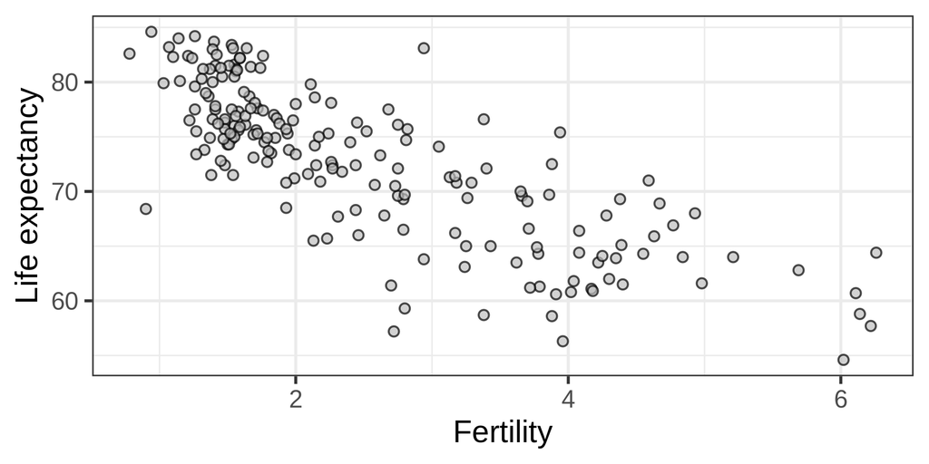

## Covariance

$$S_{xy} = \frac{\sum_{i=1}^n \bigl(x_i - \bar{x}\bigr)\bigl(y_i - \bar{y}\bigr)}{n} = \frac{SP_{xy}}{n}$$

Definitions:

- $x$ and $y$: the two variables we’re interested in.
- $\bar{x}$: the sample mean of the variable $x$.
- $x_i$: the $i$th observation of the variable.
- $n$ the sample size.
- $\sum_{i=1}^{n}$: the sum from $i$ is 1 to $i$ is $n$.
- $SP_{xy}$ the sum of products between $x$ and $y$.

$S_{xy}$ = -6.84.

## Correlation: Standardized Covariance

$$r_{xy} = \frac{\sum_{i=1}^n \bigl(x_i - \bar{x}\bigr)\bigl(y_i - \bar{y}\bigr)}{ns_xs_y} = \frac{SP_{xy}}{ns_xs_y} = \frac{S_{xy}}{s_xs_y}$$

Definitions:

- $x$ and $y$: the two variables we’re interested in.
- $\bar{x}$: the sample mean of the variable $x$.
- $x_i$: the $i$th observation of the variable.
- $n$ the sample size.
- $\sum_{i=1}^{n}$: the sum from $i$ is 1 to $i$ is $n$.
- $SP_{xy}$: the sum of products between $x$ and $y$.
- $s_x$: the sample standard deviation of $x$

$r_{xy}$ = -0.791.

## Correlation: Standardized Covariance

Recall $Z$-scores, $Z_{x_i} = \frac{x_i-\bar{x}}{s_x}$ and $Z_{y_i} = \frac{y_i-\bar{y}}{s_y}$

$$\begin{align}
r_{xy} &= \frac{\sum_{i=1}^n \bigl(x_i - \bar{x}\bigr)\bigl(y_i - \bar{y}\bigr)}{ns_xs_y} \\
r_{xy} &= \frac{1}{n}\sum_{i=1}^n \frac{\bigl(x_i - \bar{x}\bigr)}{s_x}\frac{\bigl(y_i - \bar{y}\bigr)}{s_y} \\
r_{xy} &= \frac{1}{n}\sum_{i=1}^n
\underbrace{\frac{\bigl(x_i - \bar{x}\bigr)}{s_x}}_{Z_{x_i}}
\underbrace{\frac{\bigl(y_i - \bar{y}\bigr)}{s_y}}_{Z_{y_i}} \\
r_{xy} &= \frac{1}{n}\sum_{i=1}^n Z_{x_i} Z_{y_i}
\end{align}$$

## Covariance Matrix

|  | child_mortality | fertility | co2_pcap | gdp_pcap | life_expectancy | daily_income |
| --- | --- | --- | --- | --- | --- | --- |
| child_mortality | 663.66901845254 | 27.3287115325036 | -68.93166476085297 | -423932.214664673 | -149.4795726991079 | -445.9619942120034 |
| fertility | 27.3287115325036 | 1.555441776367962 | -3.350865240237784 | -19479.86362332083 | -6.872979167779499 | -20.17812271354166 |
| co2_pcap | -68.93166476085297 | -3.350865240237784 | 28.41039627222404 | 107317.2834200264 | 20.76327595167975 | 105.6530069758033 |
| gdp_pcap | -423932.214664673 | -19479.86362332083 | 107317.2834200264 | 1553199101.535382 | 141599.0546053233 | 2029933.867221133 |
| life_expectancy | -149.4795726991079 | -6.872979167779499 | 20.76327595167975 | 141599.0546053233 | 48.6951511671385 | 150.968126351468 |
| daily_income | -445.9619942120034 | -20.17812271354166 | 105.6530069758033 | 2029933.867221133 | 150.968126351468 | 2877.239890976012 |

## Correlation Matrix

|  | child_mortality | fertility | co2_pcap | gdp_pcap | life_expectancy | daily_income |
| --- | --- | --- | --- | --- | --- | --- |
| child_mortality | 1 | 0.8515729339264638 | -0.5014655288592348 | -0.4170779265941698 | -0.8315018434250524 | -0.3223622391023648 |
| fertility | 0.8515729339264638 | 1 | -0.5037504202675653 | -0.3963844467536335 | -0.7906433701420672 | -0.3016733743270418 |
| co2_pcap | -0.5014655288592348 | -0.5037504202675653 | 1 | 0.787769018756433 | 0.5606644352801363 | 0.777917922273377 |
| gdp_pcap | -0.4170779265941698 | -0.3963844467536335 | 0.787769018756433 | 1 | 0.5166842255861461 | 0.9602410933713987 |
| life_expectancy | -0.8315018434250524 | -0.7906433701420672 | 0.5606644352801363 | 0.5166842255861461 | 1 | 0.4047395485413042 |
| daily_income | -0.3223622391023648 | -0.3016733743270418 | 0.777917922273377 | 0.9602410933713987 | 0.4047395485413042 | 1 |

## Covariance vs. Correlation

### Covariance

- $-\infty < S_{xy} < \infty$
- unit, $\mathrm{unit}(x) \times \mathrm{unit}(y)$
- covariance of $x$ with $x$ equals variance
- scales with linear transformation of the data (e.g., mm to cm)
- cannot be interpreted without knowing the variances
  - but the sign tells us if the relation is positive or negative

### Correlation

- $-1 \leq r_{xy} \leq 1$
- no unit
- correlation of $x$ with $x$ equals $1$
- unaffected by changes of units (e.g., cm to mm)
- can be interpreted without knowing the variances

## Limitations

- Throughout, we’re often looking at plots of the data
- The only thing that truly conveys all information in the data… are the data themselves
- Looking at raw numbers is typically not informative, hence we use plots

## Anscombe’s Quartet

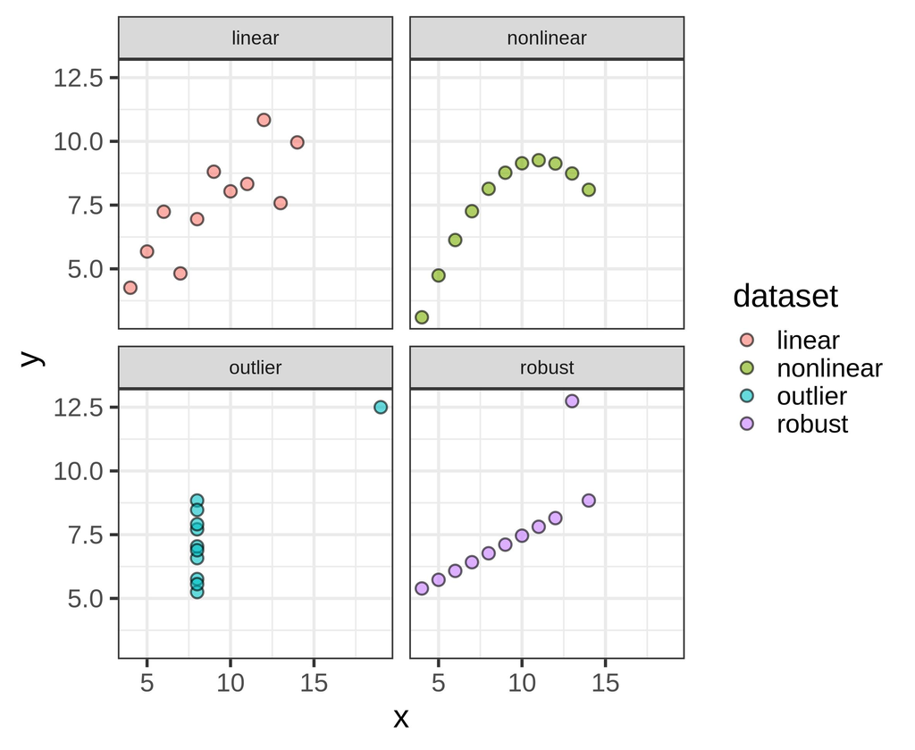

Source: [Wikipedia](https://en.wikipedia.org/wiki/Anscombe%27s_quartet)

## Anscombe’s Quartet

| dataset | mean_x | mean_y | sd_x | sd_y | cor |
| --- | --- | --- | --- | --- | --- |
| linear | 9 | 7.501 | 3.317 | 2.032 | 0.816 |
| nonlinear | 9 | 7.501 | 3.317 | 2.032 | 0.816 |
| outlier | 9 | 7.501 | 3.317 | 2.031 | 0.817 |
| robust | 9 | 7.500 | 3.317 | 2.030 | 0.816 |

## Datasaurus Dozen

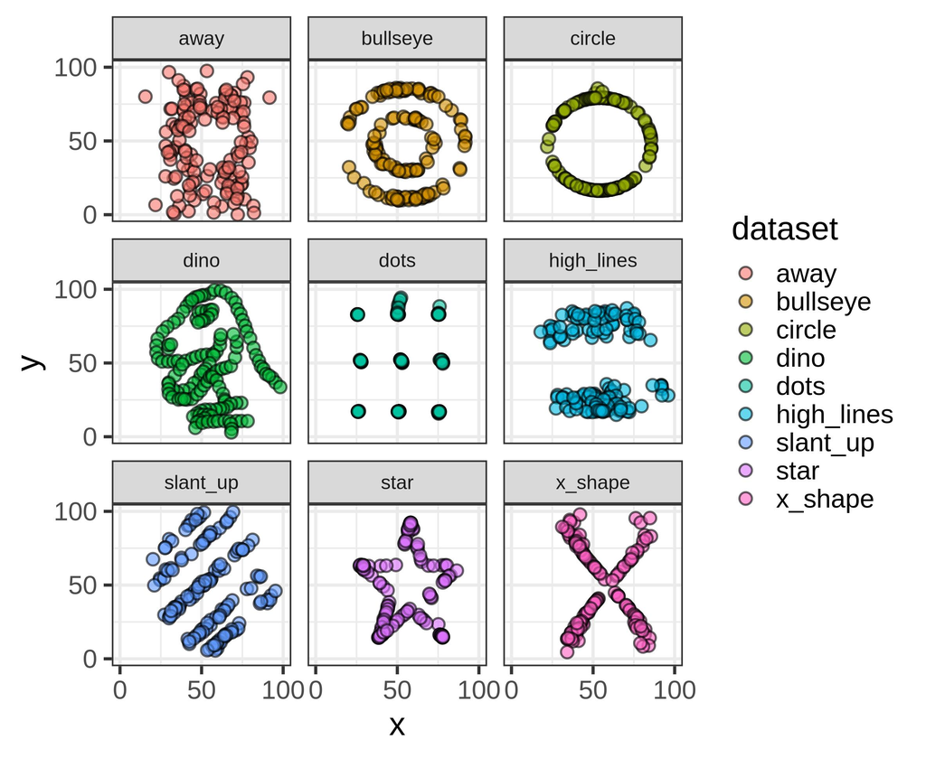

source: https://jumpingrivers.github.io/datasauRus/

## Datasaurus Dozen

| dataset | mean_x | mean_y | sd_x | sd_y | cor |
| --- | --- | --- | --- | --- | --- |
| away | 54.266 | 47.835 | 16.770 | 26.940 | -0.064 |
| bullseye | 54.269 | 47.831 | 16.769 | 26.936 | -0.069 |
| circle | 54.267 | 47.838 | 16.760 | 26.930 | -0.068 |
| dino | 54.263 | 47.832 | 16.765 | 26.935 | -0.064 |
| dots | 54.260 | 47.840 | 16.768 | 26.930 | -0.060 |
| high_lines | 54.269 | 47.835 | 16.767 | 26.940 | -0.069 |
| slant_up | 54.266 | 47.831 | 16.769 | 26.939 | -0.069 |
| star | 54.267 | 47.840 | 16.769 | 26.930 | -0.063 |
| x_shape | 54.260 | 47.840 | 16.770 | 26.930 | -0.066 |

## Limitations (2)

Some limitations cannot be spotted by looking at a plot!

1. Restricted range
2. Causality

## Restricted range

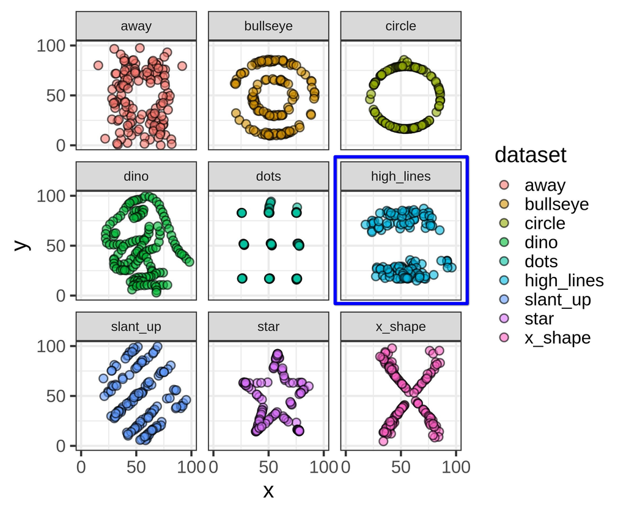

## Restricted range

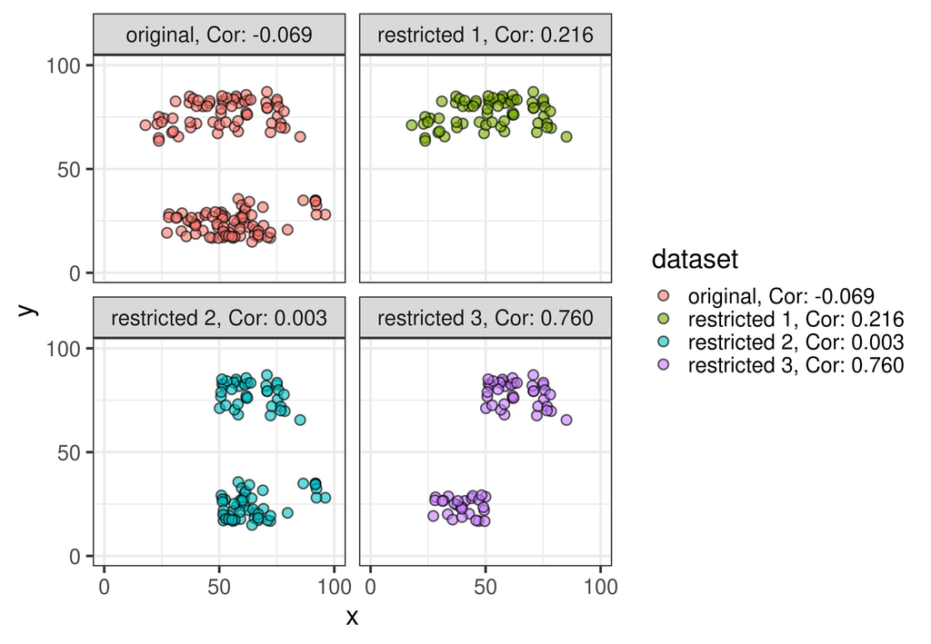

## Causality

What do these correlations tell us about causality, i.e., which variable *causes* a change in another?

Nothing! *Correlation does not imply causation*!

# Break

See you in ~10 minutes!

# Transformations

## Example: Wealth

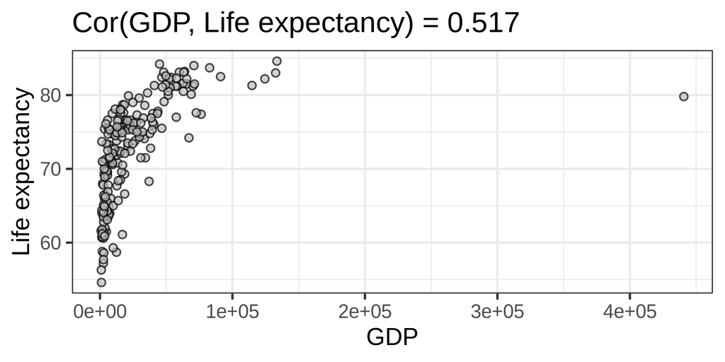

## What if the relation is not linear?

- Transformations
- Spearman rank correlation
- Kendall’s tau

## Transformations

Transformations can make

- the data more normal
- relations more linear

which in turn makes statistics easier.

But, transformations also

- alter the meaning of the data
- are not guaranteed to make things better

## Common transformations

Some we have already seen!

Converting raw to Z scores, is technically a transformation.

- Log, log10, reciprocal, exp, power, square root

## Common transformations

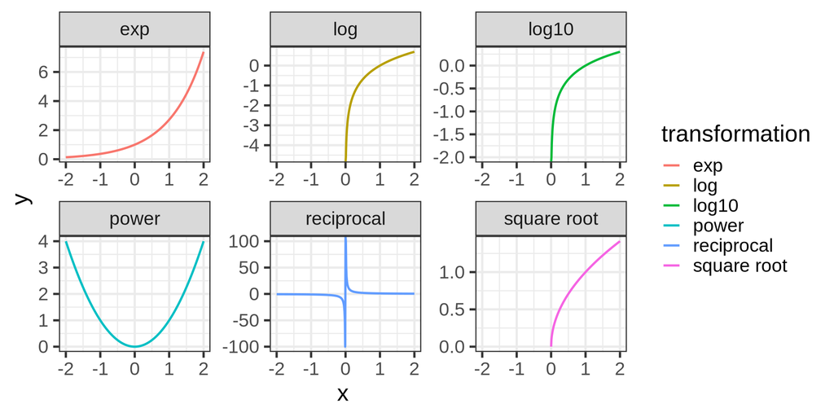

## Example: Wealth

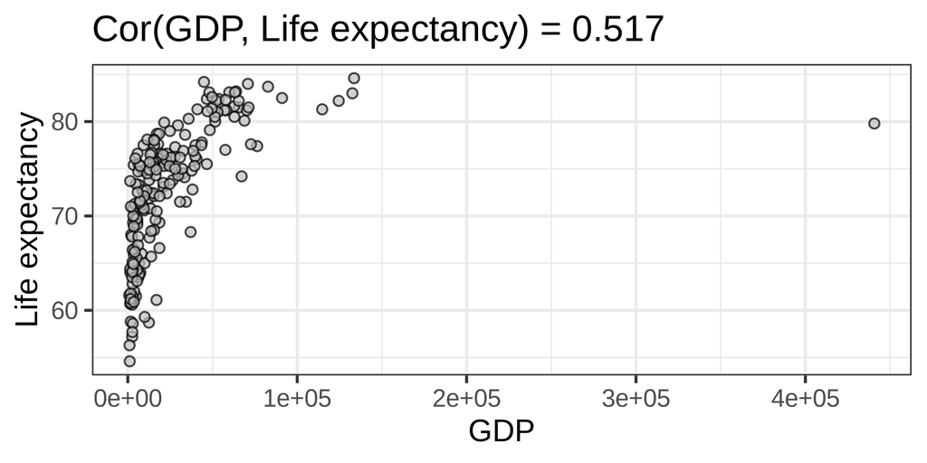

## Example: Wealth

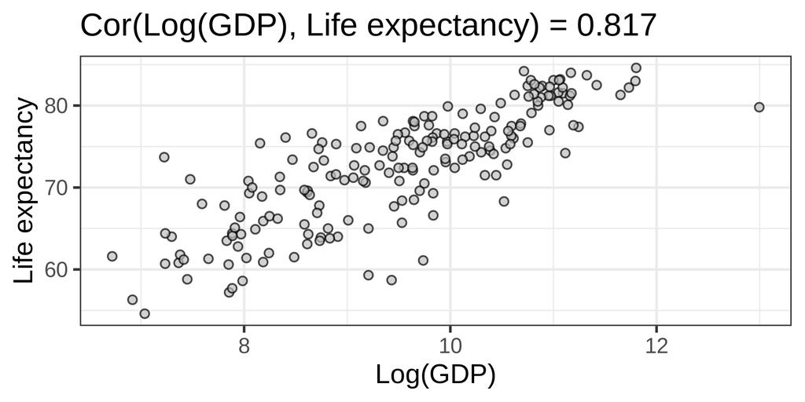

## Example: Wealth

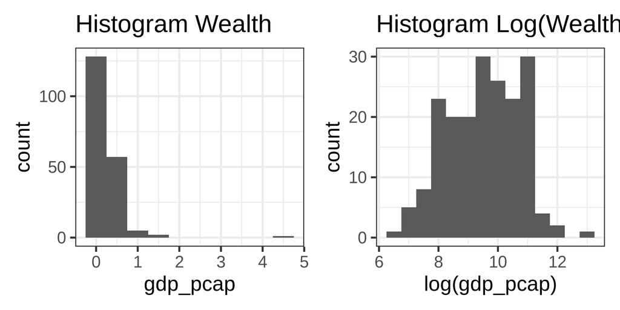

## Spearman rank correlation

Pearson correlation between the rank values of those two variables

| gdp_pcap | rank_gd | life_expectancy | rank_life_expectancy |
| --- | --- | --- | --- |
| 1981.71017 | 13 | 68 | 50 |
| 7397.48643 | 65 | 64 | 27.5 |
| 17111.95393 | 106 | 78.7 | 154.5 |
| 63913.38351 | 177 | 83.2 | 189 |
| 68867.82593 | 181 | 80.1 | 162 |
| 27627.96348 | 131 | 76.3 | 130.5 |
| 17886.17839 | 109 | 77.6 | 147.5 |
| 27941.78515 | 132 | 77.3 | 141 |
| 59883.64704 | 173 | 83.1 | 187 |
| 65661.45219 | 179 | 81.5 | 174.5 |

[output cut: 10 more lines]

## Example: Wealth

- Pearson Correlation: 0.517
- Spearman rank Correlation: 0.83
- Kendall’s Tau: 0.638

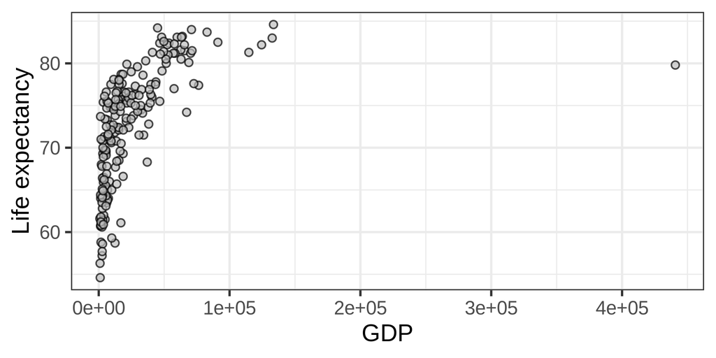

## Example: Wealth

- Pearson Correlation: 0.817
- Spearman rank Correlation: 0.83
- Kendall’s Tau: 0.638

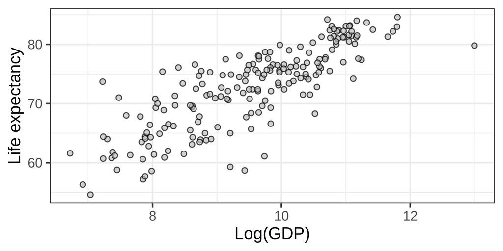

## Sample statistics and Population Estimators

- Sample statistics describe the sample.
- What we want to describe is the *population*.
- For this reason, sample statistics are often “adjusted”:

### Sample

- Variance divides by $n$
- Covariance divides by $n$

### Estimator

- Variance divides by $n - 1$
- Covariance divides by $n - 1$

Intuition: We “used” one observation to compute the sample mean and thus divide by $n - 1$.

Note:

- Variance and covariance change when we use $n-1$ to estimate population quantities
- Correlation does not change, because the denominator cancels.

## Drawbacks of Descriptive Statistics

At its core, statistics tries to *reduce* the information in the full dataset into something smaller

- (+) This makes it possible to understand large datasets
- (-) This loses information along the way

Example: **IF** the data are normally distributed then the mean and variance describe the entire distribution.

# Bivariate Distributions

## Normal distribution

Last Week: Sample mean and SD correspond to the population model $N(\mu_x, \sigma_x)$

Now: two sample means, $\bar{x},\bar{y}$, two SDs, $s_x,s_y$, a correlation $r_{xy}$ correspond to a bivariate normal model:

$$X, Y \sim N(\underbrace{\mu_x, \mu_y}_{\text{mean}}, \underbrace{\sigma_x, \sigma_y, \rho}_{\text{covariance}})$$

The bivariate normal distribution has five parameters:

$$\begin{align}
\mu_x &:\text{mean of X}\quad &&\sigma_x :\text{sd of X}\\
\mu_y &:\text{mean of Y}\quad &&\sigma_y :\text{sd of Y}\\
& \quad&&\rho :\text{correlation}
\end{align}$$

## These are the same picture

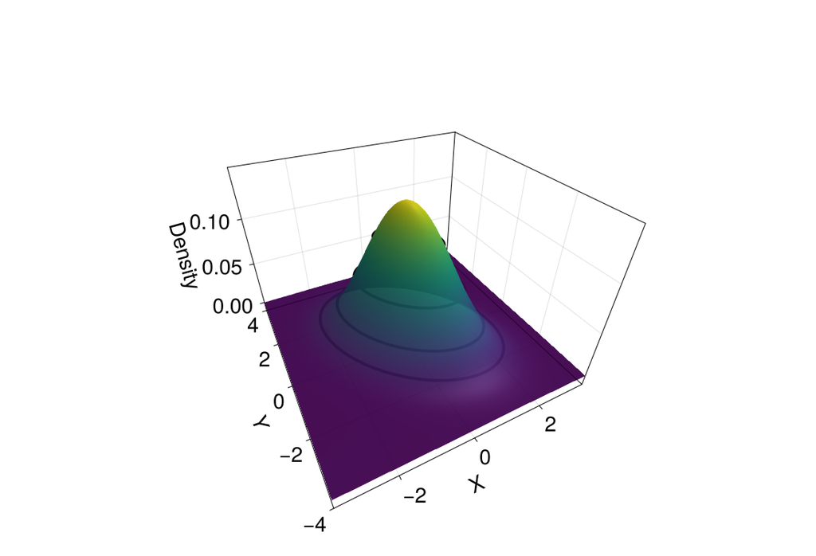

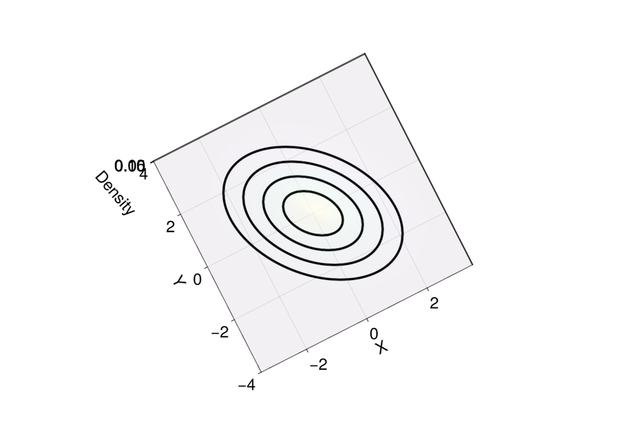

## Continuous Distributions

Last week we examined discrete probability distributions:

- joint, marginal, and conditional.

For continuous probability distributions the exact counterparts exist.

## Marginal Distribution

If we ignore $Y$, or have not observed it, what is the distribution of $X$?

Conveniently, if

$$X, Y \sim N(\underbrace{\mu_x, \mu_y}_{\text{mean}}, \underbrace{\sigma_x, \sigma_y, \rho}_{\text{(Co)Variance}})$$

then the marginal distributions are
$$X \sim N(\mu_x, \sigma_x), \quad Y \sim N(\mu_y, \sigma_y)$$

## Conditional Distribution

What if we do know $Y$?

## Conditional Distribution

If $\rho = 0$ then knowing Y does not tell us anything about X.

They are *independent*.

Independence: knowing the outcome or value of one variable or event provides no information about the probability or outcome of another.

This is a special property of the bivariate normal distribution, it does *not* hold in general that $\rho = 0$ (or $r = 0$) implies independence.

## Multivariate Normal distribution

For $p$ variables we have:
$$\mathbf{\mu} = \begin{bmatrix}
\mu_1 \\
\mu_2 \\
\mu_3 \\
\vdots \\
\mu_p
\end{bmatrix}\quad
\mathbf{\Sigma} = \begin{bmatrix}
\sigma_1^2 & \sigma_1\sigma_2\rho_{12} &\sigma_1\sigma_3\rho_{13} &\cdots &\sigma_1\sigma_p\rho_{1p}\\
\sigma_2\sigma_1\rho_{21} & \sigma_2^2 &\sigma_2\sigma_3\rho_{23} &\cdots &\sigma_2\sigma_p\rho_{2p}\\
\sigma_3\sigma_1\rho_{31} & \sigma_3\sigma_2\rho_{32} & \sigma_3^2 &\cdots &\sigma_3\sigma_p\rho_{3p}\\
\vdots & \vdots & \vdots &\ddots &\vdots \\
\sigma_p\sigma_1\rho_{p1} & \sigma_p\sigma_2\rho_{p2} & \sigma_p\sigma_3\rho_{p3} &\cdots &\sigma_p^2
\end{bmatrix}$$

- No more picture
- If $\rho_{ij} = 0$ then variables $i$ and $j$ are independent

## Summary

- Covariance and correlation summarize the association between two variables.
- Transformations and rank correlations may help when the relation is nonlinear.
- The bivariate normal distribution describes the joint, marginal, conditional distributions and independence.